# JWheelerCaseStudyUnit6

Jessica Wheeler

Due June 20, 2016

## Introduction

> In this case study, we examine 2 datasets from the World Bank: one titled “GDP” containing the GDP ranking for countries and more, and one entited “Education” containing income groups and more information on each country. We will merge these datasets, explore the merged dataset and examine how GDP ranking relates to income group.

## Loading, Cleaning, and Merging the datasets

```r
#This makefile sources r code to load, clean, then merge the two datasets:
source("Makefile.R")
#Once sourced, we have an object called merged which contains columns 1-6 of the merged dataset with information on countrycode, GDPranking, country, millionsUSdollars, and income.group.

#Check NA's:
sum(is.na(merged))
```

```
## [1] 137
```

# Questions

**1. Match the data based on country short code. How many of the IDs match?**  
* In this step, first we check how many country shortcodes are in each individual dataset.  
* In order to accomplish this, I’ve created a vector for the column countrycode in each dataset.

```r
#Checking the country shortcodes for gdpdata:
gdpcc <- gdpdata[, 1]
gdpcc
```

```
##   [1] "USA" "CHN" "JPN" "DEU" "FRA" "GBR" "BRA" "RUS" "ITA" "IND" "CAN"
##  [12] "AUS" "ESP" "MEX" "KOR" "IDN" "TUR" "NLD" "SAU" "CHE" "SWE" "IRN"
##  [23] "NOR" "POL" "BEL" "ARG" "AUT" "ZAF" "VEN" "COL" "THA" "ARE" "DNK"
##  [34] "MYS" "SGP" "CHL" "HKG" "EGY" "NGA" "ISR" "PHL" "GRC" "FIN" "PAK"
##  [45] "PRT" "IRL" "IRQ" "DZA" "PER" "KAZ" "CZE" "ROM" "UKR" "QAT" "NZL"
##  [56] "KWT" "VNM" "HUN" "BGD" "AGO" "PRI" "MAR" "SVK" "ECU" "SYR" "OMN"
##  [67] "CUB" "AZE" "BLR" "LKA" "HRV" "DOM" "SDN" "LUX" "UZB" "BGR" "GTM"
##  [78] "URY" "TUN" "SVN" "CRI" "MAC" "LBN" "LTU" "ETH" "GHA" "KEN" "SRB"
##  [89] "PAN" "YEM" "TKM" "JOR" "BHR" "LVA" "TZA" "BOL" "PRY" "CMR" "CIV"
## [100] "SLV" "TTO" "CYP" "EST" "ZMB" "AFG" "UGA" "NPL" "HND" "GAB" "GNQ"
## [111] "BIH" "ZAR" "BRN" "GEO" "PNG" "JAM" "BWA" "MOZ" "SEN" "KHM" "COG"
## [122] "ISL" "NAM" "TCD" "ALB" "NIC" "MUS" "BFA" "MLI" "MNG" "SSD" "MDG"
## [133] "ARM" "ZWE" "MKD" "LAO" "MLT" "BHS" "HTI" "BEN" "MDA" "RWA" "TJK"
## [144] "NER" "KGZ" "KSV" "MCO" "GIN" "BMU" "SUR" "MNE" "MWI" "BRB" "MRT"
## [155] "FJI" "TGO" "SLE" "SWZ" "ERI" "GUY" "ABW" "BDI" "LSO" "MDV" "CAF"
## [166] "CPV" "BTN" "LBR" "BLZ" "TMP" "LCA" "ATG" "SYC" "SLB" "GMB" "GNB"
## [177] "VUT" "GRD" "KNA" "VCT" "WSM" "COM" "DMA" "TON" "FSM" "STP" "PLW"
## [188] "MHL" "KIR" "TUV"
```

```r
#Checking the country shortcodes for educationdata:
educationcc <- educationdata[, 1]
educationcc
```

```
##   [1] "ABW" "ADO" "AFG" "AGO" "ALB" "ARE" "ARG" "ARM" "ASM" "ATG" "AUS"
##  [12] "AUT" "AZE" "BDI" "BEL" "BEN" "BFA" "BGD" "BGR" "BHR" "BHS" "BIH"
##  [23] "BLR" "BLZ" "BMU" "BOL" "BRA" "BRB" "BRN" "BTN" "BWA" "CAF" "CAN"
##  [34] "CHE" "CHI" "CHL" "CHN" "CIV" "CMR" "COG" "COL" "COM" "CPV" "CRI"
##  [45] "CUB" "CYM" "CYP" "CZE" "DEU" "DJI" "DMA" "DNK" "DOM" "DZA" "EAP"
##  [56] "EAS" "ECA" "ECS" "ECU" "EGY" "EMU" "ERI" "ESP" "EST" "ETH" "FIN"
##  [67] "FJI" "FRA" "FRO" "FSM" "GAB" "GBR" "GEO" "GHA" "GIN" "GMB" "GNB"
##  [78] "GNQ" "GRC" "GRD" "GRL" "GTM" "GUM" "GUY" "HIC" "HKG" "HND" "HPC"
##  [89] "HRV" "HTI" "HUN" "IDN" "IMY" "IND" "IRL" "IRN" "IRQ" "ISL" "ISR"
## [100] "ITA" "JAM" "JOR" "JPN" "KAZ" "KEN" "KGZ" "KHM" "KIR" "KNA" "KOR"
## [111] "KSV" "KWT" "LAC" "LAO" "LBN" "LBR" "LBY" "LCA" "LCN" "LDC" "LIC"
## [122] "LIE" "LKA" "LMC" "LMY" "LSO" "LTU" "LUX" "LVA" "MAC" "MAR" "MCO"
## [133] "MDA" "MDG" "MDV" "MEA" "MEX" "MHL" "MIC" "MKD" "MLI" "MLT" "MMR"
## [144] "MNA" "MNE" "MNG" "MNP" "MOZ" "MRT" "MUS" "MWI" "MYS" "NAC" "NAM"
## [155] "NCL" "NER" "NGA" "NIC" "NLD" "NOC" "NOR" "NPL" "NZL" "OEC" "OMN"
## [166] "PAK" "PAN" "PER" "PHL" "PLW" "PNG" "POL" "PRI" "PRK" "PRT" "PRY"
## [177] "PYF" "QAT" "ROM" "RUS" "RWA" "SAS" "SAU" "SDN" "SEN" "SGP" "SLB"
## [188] "SLE" "SLV" "SMR" "SOM" "SRB" "SSA" "SSF" "STP" "SUR" "SVK" "SVN"
## [199] "SWE" "SWZ" "SYC" "SYR" "TCA" "TCD" "TGO" "THA" "TJK" "TKM" "TMP"
## [210] "TON" "TTO" "TUN" "TUR" "TUV" "TZA" "UGA" "UKR" "UMC" "URY" "USA"
## [221] "UZB" "VCT" "VEN" "VIR" "VNM" "VUT" "WBG" "WLD" "WSM" "YEM" "ZAF"
## [232] "ZAR" "ZMB" "ZWE"
```

> We see that there are 234 levels of country shortcodes for educationdata and 190 in gdpdata. When merged, there are now 235 total countrycodes so that means only **1 countrycode was added after merging.**

**2. Sort the data frame in ascending order by GDP rank (so the United States is first). What is the 13th country in the resulting data frame?**

```r
sortedrank <- merged[order(desc(merged$millionsUSdollars),merged$GDPranking),]
head(sortedrank, n=20)
```

```
##    countrycode GDPranking            country millionsUSdollars
## 1          USA          1      United States          16244600
## 2          CHN          2              China           8227103
## 3          JPN          3              Japan           5959718
## 4          DEU          4            Germany           3428131
## 5          FRA          5             France           2612878
## 6          GBR          6     United Kingdom           2471784
## 7          BRA          7             Brazil           2252664
## 8          RUS          8 Russian Federation           2014775
## 9          ITA          9              Italy           2014670
## 10         IND         10              India           1841710
## 11         CAN         11             Canada           1821424
## 12         AUS         12          Australia           1532408
## 13         ESP         13              Spain           1322965
## 14         MEX         14             Mexico           1178126
```

[output cut: 48 more lines]

> The 13th country in the dataframe is **Spain.**

**3. What are the average GDP rankings for the “High income:OECD” and “High income: Non-OECD” groups?**

- As I came across this question, I had another question: What is OECD? According to [usoecd](http://usoecd.usmission.gov/mission/overview.htmlo), it is the Organization for Economic Cooperation and Development, which is a “unique forum where governments of 34 democracies with market economies work with each other, as well as with more than 70 non-member economies to promote economic growth, prosperity, and sustainable development.”

```r
#Let's create a subset of GDP ranking and country name:
countryrank <- merged

#Let's convert GDPranking into a numeric (for some reason, when I did this before merging the datasets, the ranking became out of order after merging, so we will do this now):
countryrank$GDPranking <- as.numeric(countryrank$GDPranking)

#Check of NA's and get rid of them:
sum(is.na(countryrank))
```

```
## [1] 137
```

```r
countryrank <-na.omit(countryrank)

#We could use the tapply function to find the sum of each income group:
tapply(countryrank$GDPranking, countryrank$income.group, mean)
```

```
## High income: nonOECD    High income: OECD           Low income
##             93.73913            110.06667             66.97297
##  Lower middle income  Upper middle income
##            105.03704            106.13333
```

> As can be seen in the output above, the average GDP ranking for the High Income: OECD group is 110.066 while the average GDP ranking for the High Income: nonOECD group is 93.739.
- The output above also shows the average GDP ranking for the rest of the income groups. From this we can see that the Low income group has the lowest average GDP ranking, followed by the High Income: nonOECD group. The highest average GDP rankings are in the groups Lower middle income, upper middle income, and High income: OECD. Thus we can conclude that being in the high income group does not necessarily indicate a high average GDP ranking.

**4. Plot the GDP for all of the countries. Use ggplot2 to color the plot by Income Group.**

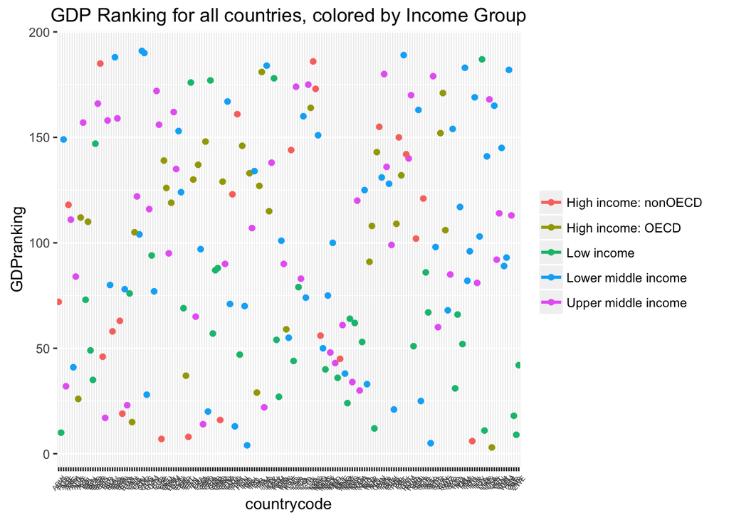

```r
#Creating the basic plot:
plot <- ggplot(countryrank, aes(countrycode, GDPranking, color=factor(income.group))) +geom_point() +stat_smooth(se = F)

#Title for the plot:
p <- plot+ggtitle('GDP Ranking for all countries, colored by Income Group')
#Turn off the legend title
p+theme(legend.title=element_blank()) +theme(axis.text.x=element_text(angle=50, size=5, vjust=0.5))
```

> The plot above appears to look like a random cloud. Although the income groups are distinguished by color, each color can be seen on each quadrant of the plot. Therefore, I think it is safe to say that there is no linear relationship between income group and GDP ranking. In other words, a high GDP ranking does not necessarily indicate that a country is in a high income group.

**5. Cut the GDP ranking into 5 separate quantile groups. Make a table vs. Income Group. How many countries are Lower middle income but among the 38 nations with highest GDP?**

```r
#GDP ranking goes from 1 to 191, we will divide the rankings into these 5 groups:
Q1 <- subset(countryrank, GDPranking <=38)
Q2 <- subset(countryrank, GDPranking >38 | GDPranking <=76)
Q3 <- subset(countryrank, GDPranking >76 | GDPranking <=114)
Q4 <- subset(countryrank, GDPranking >114 | GDPranking <=152)
Q5 <- subset(countryrank, GDPranking >=152)

#Using the code above, we can use the sum function to answer the question of how many countries are in the lower middle income group and are in Q1, among the 38 nations with the highest GDP:
sum(Q1$income.group == "Lower middle income")
```

```
## [1] 9
```

```r
#Let's create a new object with only the columns we want to make a data table- which are GDP ranking and income.group:
quantile <- countryrank[, c(2,6)]

#To make a table of the subsets Q1-Q5 vs. income group:
#First we'll convert GDPranking into a numeric vector and sort the data while assigning it to a new object:
quantile$GDPranking <- as.numeric(quantile$GDPranking)
sortedq <- quantile[order(countryrank$GDPranking),]


#Then, let's cut the data into respective quantile groups according to GDP rank and name those Q1 through Q5:
quantileranks <- cut(sortedq$GDPranking, breaks=c(-0.01, 37.99, 75.99, 113.99, 152.99, 999.99), labels=c("Q1", "Q2", "Q3", "Q4", "Q5"))

#The object quantileranks shows the sets of Q1-Q5 of the dataset.
#I'll add a new column (Q) to the data frame sortedq to contain the respective quantile groups:
sortedq$Q <- quantileranks
#Now this data set contains 3 columns: GDP ranking, income group, and Q (quantile).

#I'll subset the data and choose only the columns we want: Income group and Q:
datatable <- sortedq[, 2:3]
datatable
```

```
##             income.group  Q
## 1      High income: OECD Q1
## 10   Lower middle income Q1
## 100  Lower middle income Q1
## 101 High income: nonOECD Q1
## 102 High income: nonOECD Q1
## 103 High income: nonOECD Q1
## 104           Low income Q1
## 105           Low income Q1
## 106           Low income Q1
## 107           Low income Q1
## 108  Lower middle income Q1
## 109  Upper middle income Q1
## 11     High income: OECD Q1
## 110 High income: nonOECD Q1
```

[output cut: 175 more lines]

> As can be seen in the output above, there are 9 out of the 38 nations with the highest GDP ranking that classify as Lower middle income.

# Conclusion